# Study what factors and how they would impact the landing distance of a commercial flight

Mohammed Nifaullah Sailappai

1/31/2020

## 1. Introduction

**Background:** Flight landing.  
**Motivation:** To reduce the risk of landing overrun.  
**Goal:** To study what factors and how they would impact the landing distance of a commercial flight.  
**Approach:** Use Logistic Regression to classify risky and safe landings  
**Data:** Landing data (landing distance and other parameters) from 950 commercial flights (not real data set but simulated from statistical models).

#### Variable dictionary

**Aircraft:** The make of an aircraft (Boeing or Airbus).  
**Duration (in minutes):** Flight duration between taking off and landing. The duration of a normal flight should always be greater than 40min.  
**No_pasg:** The number of passengers in a flight.  
**Speed_ground (in miles per hour):** The ground speed of an aircraft when passing over the threshold of the runway. If its value is less than 30MPH or greater than 140MPH, then the landing would be considered as abnormal.  
**Speed_air (in miles per hour):** The air speed of an aircraft when passing over the threshold of the runway. If its value is less than 30MPH or greater than 140MPH, then the landing would be considered as abnormal.  
**Height (in meters):** The height of an aircraft when it is passing over the threshold of the runway. The landing aircraft is required to be at least 6 meters high at the threshold of the runway.  
**Pitch (in degrees):** Pitch angle of an aircraft when it is passing over the threshold of the runway.  
**Distance (in feet):** The landing distance of an aircraft. More specifically, it refers to the distance between the threshold of the runway and the point where the aircraft can be fully stopped. The length of the airport runway is typically less than 6000 feet.

## 2. Setup

All duplicates are removed and a clean dataset is setup to work with.

```r
library(ggplot2)
library(MASS)
library(dplyr)
library(faraway)
faa1 <- read.csv("C:/Users/nifaullah/Downloads/FAAc1.csv")
faa2 <- read.csv("C:/Users/nifaullah/Downloads/FAAc2.csv")
# Removing empty factor data if any
faa2 <- droplevels(subset(faa2, aircraft != ""))
# Creating the missing column duration in faa2 before merging the datasets vertically
faa2$duration <- NA
# Merging Verically
faa <- rbind(faa1, faa2)
# Selecting duplicates minus duration as durtion was not originally present in 2nd Dataset
duplicate_rows <- faa  %>%
  select(-duration) %>%
  duplicated() %>%
  which()
#Removing duplicates
faa <- faa[-duplicate_rows,]
# After removing duplicates
dim(faa)
```

```
## [1] 850   8
```

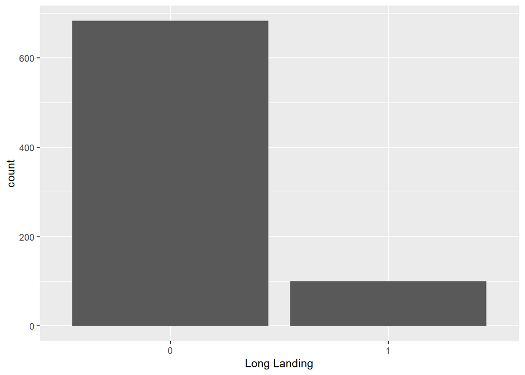

```r
# Remove all abnormal rows as per the dictionary definition
faa_normal <- faa %>%
  filter(duration >40,
         (speed_ground >=30 | speed_ground <=140),
         (is.na(speed_air) | speed_air >=30 | speed_air <=140),
         height >=6, distance < 6000)
# Creatinng Binary variables for classification
faa_normal$long.landing <- ifelse(faa_normal$distance > 2500, 1, 0)
faa_normal$long.landing <- as.factor(faa_normal$long.landing)
faa_normal$risky.landing <- ifelse(faa_normal$distance > 3000, 1, 0)
faa_normal$risky.landing <- as.factor(faa_normal$risky.landing)
faa_normal$aircraft <- as.factor(faa_normal$aircraft)
#Removing Distance Column
faa_normal <- subset(faa_normal, select = -c(distance))
#Histogram for Risky Landing
ggplot(faa_normal, aes(x=long.landing)) +
   labs(x="Long Landing") +
    geom_bar()
```

## 3.Regression using a single feature each time

Regressing Y (Long Landing) on each of the X variables. Only 3 variables Aircraft, Speed Ground and Speed Air are significant rest all are insignificant if regressed independently.

```r
table1 <- data.frame()
for(i in 1:7)
{
  model <- glm(long.landing~faa_normal[,i], faa_normal, family=binomial)
  table1 <- rbind(table1, data.frame(variable = names(faa_normal[,i,drop=FALSE]),
                   coeff_size = abs(model$coefficients[2]),
                   coeff_direction = ifelse(model$coefficients[2] >= 0, "Positive", "Negative"),
                   odds_ratio = exp(model$coefficients[2]),
                   p_value = round(summary(model)$coefficients[-1,c(1,4)][2],2),
                   row.names = NULL)
  )
}
table1 %>%
  arrange(p_value)
```

```
##       variable  coeff_size coeff_direction odds_ratio p_value
## 1     aircraft 0.822511471        Positive  2.2762093    0.00
## 2 speed_ground 0.476544128        Positive  1.6104991    0.00
## 3    speed_air 0.522336368        Positive  1.6859621    0.00
## 4        pitch 0.329267542        Positive  1.3899497    0.11
## 5       height 0.007187664        Positive  1.0072136    0.51
## 6     duration 0.001099396        Negative  0.9989012    0.62
## 7      no_pasg 0.006575058        Negative  0.9934465    0.64
```

## 4. Checking Association with Significant variables

1. Boeing has slightly higher long landings compared to Airbus.
2. As explained the positive correlation above long landing with increase in speed grund & speed air

### Aircraft

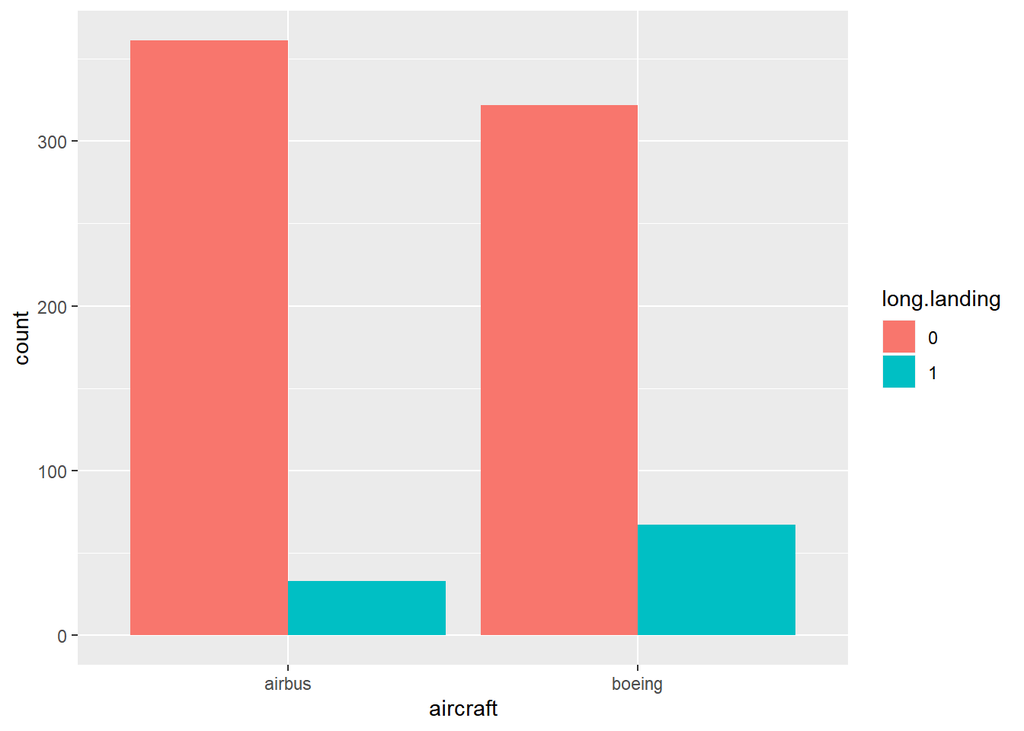

```r
ggplot(faa_normal, aes(x=aircraft, fill=long.landing)) +
    geom_bar(position = 'dodge')
```

### Speed Air

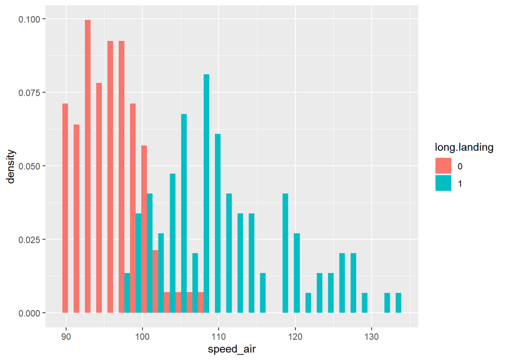

```r
ggplot(faa_normal, aes(x=speed_air, fill=long.landing)) +
    geom_histogram(position = 'dodge', aes(y=..density..))
```

### Speed Ground

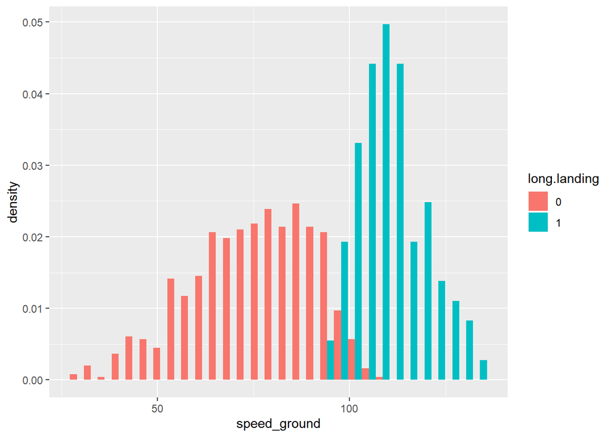

```r
ggplot(faa_normal, aes(x=speed_ground, fill=long.landing)) +
    geom_histogram(position = 'dodge', aes(y=..density..))
```

## 5. Checking for Collinearity

1. Speed air, height and aircraft are the significant variables.
2. Additionally Speed Ground has a negative sign whereas we earlier observed that speed ground increases with increase in long landing suggesting some effects of multi-collinearity. We will remove Speed Air from the dataset & only pick Speed Ground instead, as Speed Air has close 600 values missing.
3. The model is incosistent with earlier results

```r
full_model <- glm(long.landing ~ ., data=faa_normal, family=binomial)
summary(full_model)
```

```
##
## Call:
## glm(formula = long.landing ~ ., family = binomial, data = faa_normal)
##
## Deviance Residuals:
##      Min        1Q    Median        3Q       Max
## -2.48513  -0.01382   0.00000   0.00000   1.56909
##
## Coefficients:
##                  Estimate Std. Error z value Pr(>|z|)
## (Intercept)    -1.959e+02  5.627e+01  -3.481 0.000499 ***
## aircraftboeing  8.766e+00  2.628e+00   3.335 0.000852 ***
## duration        3.121e-04  1.046e-02   0.030 0.976209
## no_pasg        -7.327e-02  7.015e-02  -1.044 0.296317
## speed_ground   -2.247e-01  3.842e-01  -0.585 0.558636
## speed_air       1.980e+00  7.098e-01   2.790 0.005277 **
## height          4.216e-01  1.431e-01   2.946 0.003221 **
## pitch           1.463e+00  1.057e+00   1.384 0.166281
## risky.landing1  1.113e+01  2.124e+03   0.005 0.995819
## ---
## Signif. codes:  0 '***' 0.001 '**' 0.01 '*' 0.05 '.' 0.1 ' ' 1
##
## (Dispersion parameter for binomial family taken to be 1)
##
##     Null deviance: 270.199  on 194  degrees of freedom
## Residual deviance:  32.898  on 186  degrees of freedom
##   (588 observations deleted due to missingness)
## AIC: 50.898
##
## Number of Fisher Scoring iterations: 20
```

```r
faa_normal <- subset(faa_normal, select = -c(speed_air))
full_model <- glm(long.landing ~ ., data=faa_normal, family=binomial)
```

## 6. Stepwise Forward AIC

The results of stepwise AIC are not consistent with the results of the single variable regression. Here the significant variables are aircraft, speed_ground, height & pitch.

```r
full_model_forward_aic <- step(full_model)
```

```
## Start:  AIC=66.72
## long.landing ~ aircraft + duration + no_pasg + speed_ground +
##     height + pitch + risky.landing
```

```
##                 Df Deviance    AIC
## - no_pasg        1   50.750  64.75
## - risky.landing  1   51.084  65.08
## - duration       1   51.222  65.22
## <none>               50.718  66.72
## - pitch          1   52.886  66.89
## - height         1   72.221  86.22
## - aircraft       1   84.242  98.24
## - speed_ground   1  303.019 317.02
```

```
##
## Step:  AIC=64.75
## long.landing ~ aircraft + duration + speed_ground + height +
##     pitch + risky.landing
```

```
##                 Df Deviance     AIC
## - risky.landing  1   51.102  63.102
## - duration       1   51.235  63.235
## <none>               50.750  64.750
## - pitch          1   52.919  64.919
## - height         1   73.094  85.094
## - aircraft       1   84.272  96.272
## - speed_ground   1  303.813 315.813
```

```
##
## Step:  AIC=63.1
## long.landing ~ aircraft + duration + speed_ground + height +
##     pitch
```

```
##                Df Deviance    AIC
## - duration      1    51.58  61.58
## <none>               51.10  63.10
## - pitch         1    53.68  63.68
## - height        1    73.47  83.47
## - aircraft      1    85.86  95.86
## - speed_ground  1   583.54 593.54
```

```
##
## Step:  AIC=61.58
## long.landing ~ aircraft + speed_ground + height + pitch
```

```
##                Df Deviance    AIC
## <none>               51.58  61.58
## - pitch         1    54.40  62.40
## - height        1    75.18  83.18
## - aircraft      1    86.06  94.06
## - speed_ground  1   583.66 591.66
```

## 7. Stepwise Forward BIC

The results of stepwise BIC are consistent with the results of The results of stepwise AIC. Here again the significant variables are aircraft, speed_ground, height & pitch.

```r
full_model_forward_bic <- step(full_model, k = log(length(faa_normal)))
```

```
## Start:  AIC=67.35
## long.landing ~ aircraft + duration + no_pasg + speed_ground +
##     height + pitch + risky.landing
```

```
##                 Df Deviance    AIC
## - no_pasg        1   50.750  65.31
## - risky.landing  1   51.084  65.64
## - duration       1   51.222  65.78
## <none>               50.718  67.35
## - pitch          1   52.886  67.44
## - height         1   72.221  86.78
## - aircraft       1   84.242  98.80
## - speed_ground   1  303.019 317.58
```

```
##
## Step:  AIC=65.31
## long.landing ~ aircraft + duration + speed_ground + height +
##     pitch + risky.landing
```

```
##                 Df Deviance    AIC
## - risky.landing  1   51.102  63.58
## - duration       1   51.235  63.71
## <none>               50.750  65.31
## - pitch          1   52.919  65.40
## - height         1   73.094  85.57
## - aircraft       1   84.272  96.75
## - speed_ground   1  303.813 316.29
```

```
##
## Step:  AIC=63.58
## long.landing ~ aircraft + duration + speed_ground + height +
##     pitch
```

```
##                Df Deviance    AIC
## - duration      1    51.58  61.98
## <none>               51.10  63.58
## - pitch         1    53.68  64.08
## - height        1    73.47  83.86
## - aircraft      1    85.86  96.26
## - speed_ground  1   583.54 593.94
```

```
##
## Step:  AIC=61.98
## long.landing ~ aircraft + speed_ground + height + pitch
```

```
##                Df Deviance    AIC
## <none>               51.58  61.98
## - pitch         1    54.40  62.72
## - height        1    75.18  83.49
## - aircraft      1    86.06  94.37
## - speed_ground  1   583.66 591.98
```

## 8. Final Model for Long Landings

```r
final_model_long_landings <- glm(long.landing ~ aircraft + speed_ground + height, data=faa_normal, family=binomial)
summary(final_model_long_landings)
```

```
##
## Call:
## glm(formula = long.landing ~ aircraft + speed_ground + height,
##     family = binomial, data = faa_normal)
##
## Deviance Residuals:
##      Min        1Q    Median        3Q       Max
## -2.35721  -0.00160  -0.00001   0.00000   2.55053
##
## Coefficients:
##                 Estimate Std. Error z value Pr(>|z|)
## (Intercept)    -98.86483   18.64743  -5.302 1.15e-07 ***
## aircraftboeing   4.91354    1.10438   4.449 8.62e-06 ***
## speed_ground     0.88939    0.16684   5.331 9.79e-08 ***
## height           0.22063    0.06028   3.660 0.000252 ***
## ---
## Signif. codes:  0 '***' 0.001 '**' 0.01 '*' 0.05 '.' 0.1 ' ' 1
##
## (Dispersion parameter for binomial family taken to be 1)
##
##     Null deviance: 598.240  on 782  degrees of freedom
## Residual deviance:  54.401  on 779  degrees of freedom
## AIC: 62.401
##
## Number of Fisher Scoring iterations: 11
```

## 9.1 Regression using a single feature each time

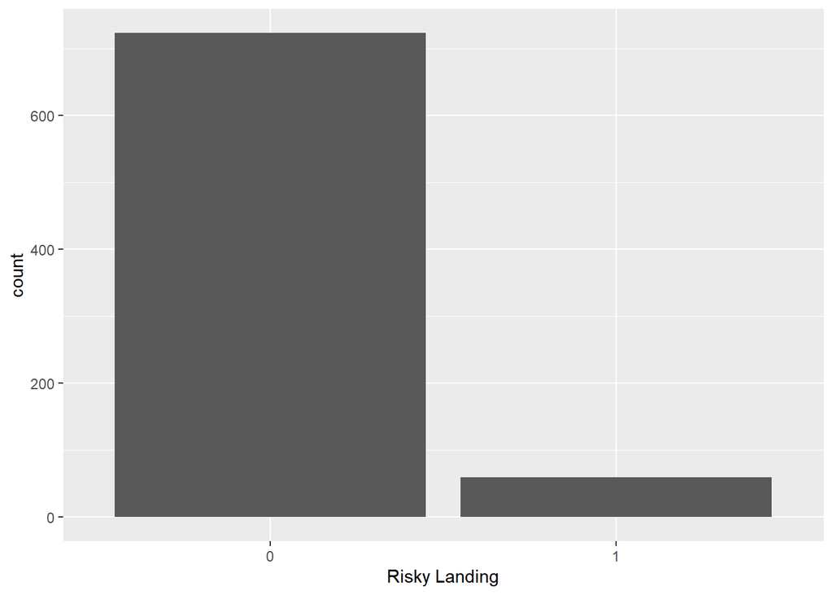

```r
#Histogram for Risky Landing
ggplot(faa_normal, aes(x=risky.landing)) +
   labs(x="Risky Landing") +
    geom_bar()
```

```r
table1 <- data.frame()
for(i in 1:7)
{
  model <- glm(risky.landing~faa_normal[,i], faa_normal, family=binomial)
  table1 <- rbind(table1, data.frame(variable = names(faa_normal[,i,drop=FALSE]),
                   coeff_size = abs(model$coefficients[2]),
                   coeff_direction = ifelse(model$coefficients[2] >= 0, "Positive", "Negative"),
                   odds_ratio = exp(model$coefficients[2]),
                   p_value = round(summary(model)$coefficients[-1,c(1,4)][2],2),
                   row.names = NULL)
  )
}
table1 %>%
  arrange(p_value)
```

```
##       variable   coeff_size coeff_direction   odds_ratio p_value
## 1     aircraft  0.927562200        Positive 2.528338e+00    0.00
## 2 speed_ground  0.598546052        Positive 1.819471e+00    0.00
## 3      no_pasg  0.025123978        Negative 9.751890e-01    0.16
## 4        pitch  0.330158961        Positive 1.391189e+00    0.20
## 5     duration  0.001179390        Negative 9.988213e-01    0.67
## 6       height  0.003907378        Negative 9.961002e-01    0.78
## 7 long.landing 21.971533618        Positive 3.484302e+09    0.98
```

## 9.2. Checking Association with Significant variables

1. Again Boeing has slightly higher risky landings compared to Airbus.
2. As earlier risky landing increases with increase in speed groud.

### Aircraft

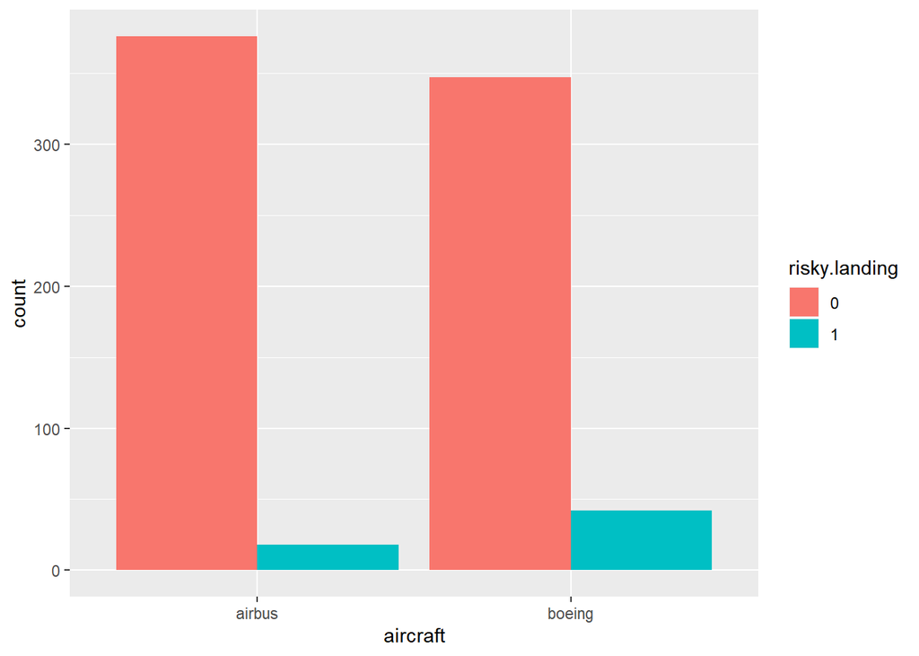

```r
ggplot(faa_normal, aes(x=aircraft, fill=risky.landing)) +
    geom_bar(position = 'dodge')
```

### Speed Ground

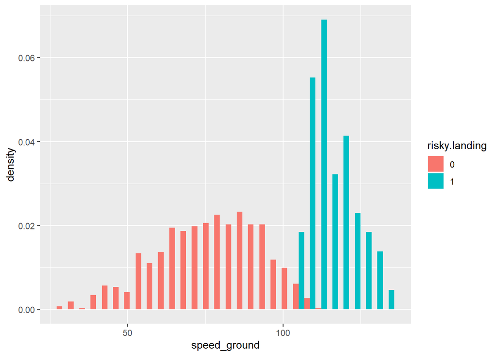

```r
ggplot(faa_normal, aes(x=speed_ground, fill=risky.landing)) +
    geom_histogram(position = 'dodge', aes(y=..density..))
```

## 11. Checking for Collinearity 1. Speed Ground and aircraft are the significant variables. 2. Additionally any possible collinearity was removed with the removal of speed_air

```r
full_model <- glm(risky.landing ~ ., data=faa_normal, family=binomial)
summary(full_model)
```

```
##
## Call:
## glm(formula = risky.landing ~ ., family = binomial, data = faa_normal)
##
## Deviance Residuals:
##    Min      1Q  Median      3Q     Max
## -2.423   0.000   0.000   0.000   1.850
##
## Coefficients:
##                  Estimate Std. Error z value Pr(>|z|)
## (Intercept)    -1.135e+02  2.686e+03  -0.042  0.96630
## aircraftboeing  4.271e+00  1.583e+00   2.698  0.00698 **
## duration        3.038e-04  1.204e-02   0.025  0.97987
## no_pasg        -8.492e-02  5.999e-02  -1.416  0.15692
## speed_ground    9.093e-01  2.521e-01   3.607  0.00031 ***
## height          4.001e-02  4.618e-02   0.866  0.38634
## pitch           5.735e-01  8.002e-01   0.717  0.47359
## long.landing1   1.459e+01  2.686e+03   0.005  0.99567
## ---
## Signif. codes:  0 '***' 0.001 '**' 0.01 '*' 0.05 '.' 0.1 ' ' 1
##
## (Dispersion parameter for binomial family taken to be 1)
##
##     Null deviance: 423.535  on 782  degrees of freedom
## Residual deviance:  36.171  on 775  degrees of freedom
## AIC: 52.171
##
## Number of Fisher Scoring iterations: 23
```

## 9.3 Stepwise Forward AIC

```r
full_model_forward_aic <- step(full_model)
```

```
## Start:  AIC=52.17
## risky.landing ~ aircraft + duration + no_pasg + speed_ground +
##     height + pitch + long.landing
```

```
##                Df Deviance     AIC
## - duration      1   36.171  50.171
## - long.landing  1   36.372  50.372
## - pitch         1   36.695  50.695
## - height        1   36.942  50.942
## <none>              36.171  52.171
## - no_pasg       1   38.376  52.376
## - aircraft      1   48.174  62.174
## - speed_ground  1  130.174 144.174
```

```
##
## Step:  AIC=50.17
## risky.landing ~ aircraft + no_pasg + speed_ground + height +
##     pitch + long.landing
```

```
##                Df Deviance     AIC
## - long.landing  1   36.376  48.376
## - pitch         1   36.728  48.728
## - height        1   36.989  48.989
## <none>              36.171  50.171
## - no_pasg       1   38.517  50.517
## - aircraft      1   48.181  60.181
## - speed_ground  1  130.186 142.186
```

```
##
## Step:  AIC=48.38
## risky.landing ~ aircraft + no_pasg + speed_ground + height +
##     pitch
```

```
##                Df Deviance    AIC
## - pitch         1    36.98  46.98
## - height        1    37.30  47.30
## <none>               36.38  48.38
## - no_pasg       1    38.82  48.82
## - aircraft      1    49.91  59.91
## - speed_ground  1   410.75 420.75
```

```
##
## Step:  AIC=46.98
## risky.landing ~ aircraft + no_pasg + speed_ground + height
```

```
##                Df Deviance    AIC
## - height        1    37.56  45.56
## <none>               36.98  46.98
## - no_pasg       1    39.30  47.30
## - aircraft      1    57.06  65.06
## - speed_ground  1   410.77 418.77
```

```
##
## Step:  AIC=45.56
## risky.landing ~ aircraft + no_pasg + speed_ground
```

```
##                Df Deviance    AIC
## <none>               37.56  45.56
## - no_pasg       1    39.96  45.96
## - aircraft      1    57.18  63.18
## - speed_ground  1   410.79 416.79
```

## 9.4 Stepwise Forward BIC

```r
full_model_forward_bic <- step(full_model, k = log(length(faa_normal)))
```

```
## Start:  AIC=52.81
## risky.landing ~ aircraft + duration + no_pasg + speed_ground +
##     height + pitch + long.landing
```

```
##                Df Deviance     AIC
## - duration      1   36.171  50.727
## - long.landing  1   36.372  50.928
## - pitch         1   36.695  51.251
## - height        1   36.942  51.498
## <none>              36.171  52.806
## - no_pasg       1   38.376  52.932
## - aircraft      1   48.174  62.730
## - speed_ground  1  130.174 144.730
```

```
##
## Step:  AIC=50.73
## risky.landing ~ aircraft + no_pasg + speed_ground + height +
##     pitch + long.landing
```

```
##                Df Deviance     AIC
## - long.landing  1   36.376  48.852
## - pitch         1   36.728  49.205
## - height        1   36.989  49.466
## <none>              36.171  50.727
## - no_pasg       1   38.517  50.994
## - aircraft      1   48.181  60.658
## - speed_ground  1  130.186 142.663
```

```
##
## Step:  AIC=48.85
## risky.landing ~ aircraft + no_pasg + speed_ground + height +
##     pitch
```

```
##                Df Deviance    AIC
## - pitch         1    36.98  47.38
## - height        1    37.30  47.70
## <none>               36.38  48.85
## - no_pasg       1    38.82  49.21
## - aircraft      1    49.91  60.30
## - speed_ground  1   410.75 421.14
```

```
##
## Step:  AIC=47.38
## risky.landing ~ aircraft + no_pasg + speed_ground + height
```

```
##                Df Deviance    AIC
## - height        1    37.56  45.88
## <none>               36.98  47.38
## - no_pasg       1    39.30  47.61
## - aircraft      1    57.06  65.38
## - speed_ground  1   410.77 419.09
```

```
##
## Step:  AIC=45.88
## risky.landing ~ aircraft + no_pasg + speed_ground
```

```
##                Df Deviance    AIC
## <none>               37.56  45.88
## - no_pasg       1    39.96  46.19
## - aircraft      1    57.18  63.42
## - speed_ground  1   410.79 417.03
```

## 10. Final Model for Risky Landings

```r
final_model_risky_landings <- glm(risky.landing ~ aircraft + speed_ground, data=faa_normal, family=binomial)
summary(final_model_risky_landings)
```

```
##
## Call:
## glm(formula = risky.landing ~ aircraft + speed_ground, family = binomial,
##     data = faa_normal)
##
## Deviance Residuals:
##      Min        1Q    Median        3Q       Max
## -2.22465  -0.00014   0.00000   0.00000   1.60326
##
## Coefficients:
##                 Estimate Std. Error z value Pr(>|z|)
## (Intercept)    -100.6448    24.8834  -4.045 5.24e-05 ***
## aircraftboeing    3.9763     1.2520   3.176  0.00149 **
## speed_ground      0.9132     0.2258   4.044 5.25e-05 ***
## ---
## Signif. codes:  0 '***' 0.001 '**' 0.01 '*' 0.05 '.' 0.1 ' ' 1
##
## (Dispersion parameter for binomial family taken to be 1)
##
##     Null deviance: 423.535  on 782  degrees of freedom
## Residual deviance:  39.955  on 780  degrees of freedom
## AIC: 45.955
##
## Number of Fisher Scoring iterations: 12
```

## 11. Comparison

1. Risky Landings mainly depends on Aircraft & Speed Ground
2. Long Landings mainly depends on Aircraft, Speed Ground & Height
3. In both the cases the odds massively increase if the aircraft is boeing.

## 12. ROC Curve

As we can see ROC plot for Risky Landing model appears to cover more area compared to Long Landing model it is likely that Risky Landing model has more Area Under Curve.

### Long Landings

```r
faa_normal_l<-na.omit(faa_normal) ### Remove the rows with missing values
dim(faa_normal_l)
```

```
## [1] 783   8
```

```r
model.final.l<-glm(long.landing ~ aircraft + speed_ground + height, data=faa_normal_l, family=binomial)
linpred.l<-predict(model.final.l) ### Linear predictor
predprob.l<-predict(model.final.l,type="response") ### predicted
predout.l<-ifelse(predprob.l<0.5,"no","yes") ### Predicted outcomes using
faa_normal_l<-data.frame(faa_normal_l,predprob.l,predout.l)

xtabs(~long.landing+predout.l,faa_normal_l)
```

```
##             predout.l
## long.landing  no yes
##            0 679   4
##            1   6  94
```

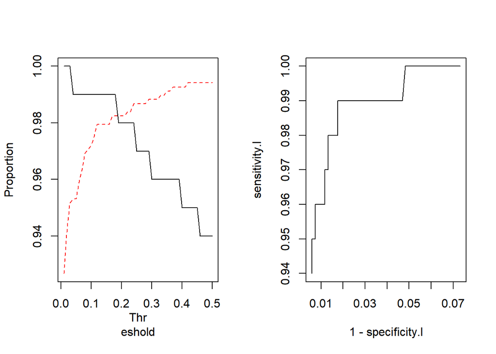

```r
thresh.l<-seq(0.01,0.5,0.01)
sensitivity.l<-specificity.l<-rep(NA,length(thresh.l))
for(j in seq(along=thresh.l)){
pp.l<-ifelse(faa_normal_l$predprob.l<thresh.l[j],"no","yes")
xx.l<-xtabs(~long.landing+pp.l,faa_normal_l)
specificity.l[j]<-xx.l[1,1]/(xx.l[1,1]+xx.l[1,2])
sensitivity.l[j]<-xx.l[2,2]/(xx.l[2,1]+xx.l[2,2])
}
par(mfrow=c(1,2))
matplot(thresh.l,cbind(sensitivity.l,specificity.l),type="l",xlab="Thr
eshold",ylab="Proportion",lty=1:2)
plot(1-specificity.l,sensitivity.l,type="l");abline(0,1,lty=2)
```

### Risky Landings

```r
faa_normal_r<-na.omit(faa_normal) ### Remove the rows with missing values
dim(faa_normal_r)
```

```
## [1] 783   8
```

```r
model.final.r<-glm(risky.landing ~ aircraft + speed_ground, data=faa_normal_r, family=binomial)
predprob.r<-predict(model.final.r,type="response") ### predicted
predout.r<-ifelse(predprob.r<0.5,"no","yes") ### Predicted outcomes using
faa_normal_r<-data.frame(faa_normal_r,predprob.r,predout.r)
xtabs(~risky.landing+predout.r,faa_normal_r)
```

```
##              predout.r
## risky.landing  no yes
##             0 717   6
##             1   6  54
```

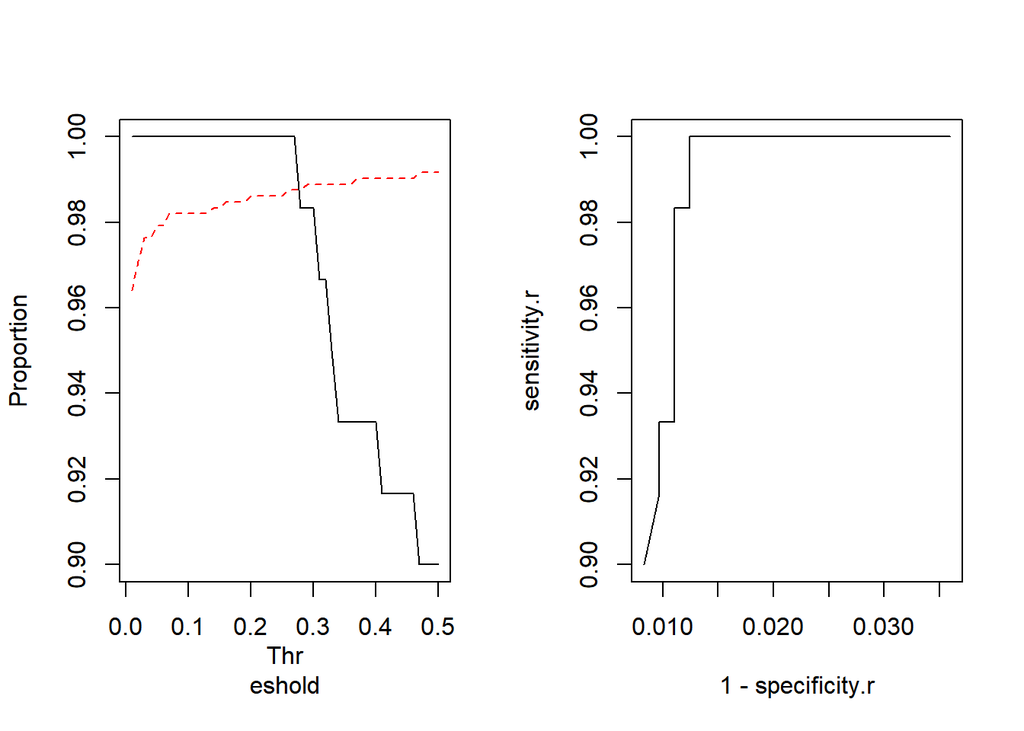

```r
thresh.r<-seq(0.01,0.5,0.01)
sensitivity.r<-specificity.r<-rep(NA,length(thresh.r))
for(j in seq(along=thresh.r)){
pp.r<-ifelse(faa_normal_r$predprob.r<thresh.r[j],"no","yes")
xx.r<-xtabs(~risky.landing+pp.r,faa_normal_r)
specificity.r[j]<-xx.r[1,1]/(xx.r[1,1]+xx.r[1,2])
sensitivity.r[j]<-xx.r[2,2]/(xx.r[2,1]+xx.r[2,2])
}
par(mfrow=c(1,2))
matplot(thresh.r,cbind(sensitivity.r,specificity.r),type="l",xlab="Thr
eshold",ylab="Proportion",lty=1:2)
plot(1-specificity.r,sensitivity.r,type="l");abline(0,1,lty=2)
```

## 13. Predicting Probability

Risky Landing model has a wider range compared to Long Landing Model.

### Long Landing

```r
new.ind<-data.frame(aircraft="boeing", duration=200, no_pasg=80, speed_ground=115, speed_air=120, height=40, pitch=4)
### Predict the value with its standard error
pred.l <- predict(model.final.l,newdata=new.ind,type="response",se=T)

upper.l <- ilogit(pred.l$fit + (1.96 * pred.l$se.fit))
lower.l <- ilogit(pred.l$fit - (1.96 * pred.l$se.fit))
fit.l <- ilogit(pred.l$fit)

cat("95% Confidence Interval", "lower:", lower.l, "| fit:" , fit.l, "| upper:", upper.l)
```

```
## 95% Confidence Interval lower: 0.7310585 | fit: 0.7310586 | upper: 0.7310586
```

### Risky Landing

```r
new.ind<-data.frame(aircraft="boeing", duration=200, no_pasg=80, speed_ground=115, speed_air=120, height=40, pitch=4)
### Predict the value with its standard error
pred.r <- predict(model.final.r,newdata=new.ind,type="response",se=T)

upper.r <- ilogit(pred.r$fit + (1.96 * pred.r$se.fit))
lower.r <- ilogit(pred.r$fit - (1.96 * pred.r$se.fit))
fit.r <- ilogit(pred.r$fit)

cat("95% Confidence Interval", "lower:", lower.r, "| fit:" , fit.r, "| upper:", upper.r)
```

```
## 95% Confidence Interval lower: 0.7308198 | fit: 0.7310119 | upper: 0.7312039
```

## 14. Comparing different Link Functions

Logit has slightly higher coefficient for both aircraft and speed_ground compared to probit and hazard both of which are similar in its estimate.

```r
model.probit.r <- glm(risky.landing ~ aircraft+speed_ground, family=binomial (link = "probit"), data=faa_normal_r)
model.hazard.r <- glm(risky.landing ~ aircraft+speed_ground, family=binomial (link = "cloglog"), data=faa_normal_r)
summary(model.final.r)$coefficients
```

```
##                    Estimate Std. Error   z value     Pr(>|z|)
## (Intercept)    -100.6447983 24.8834113 -4.044654 5.240037e-05
## aircraftboeing    3.9763497  1.2520073  3.175980 1.493315e-03
## speed_ground      0.9131614  0.2258071  4.043989 5.254930e-05
```

```r
summary(model.probit.r)$coefficients
```

```
##                   Estimate Std. Error   z value     Pr(>|z|)
## (Intercept)    -57.9659503 13.4209151 -4.319076 1.566839e-05
## aircraftboeing   2.3378746  0.7039672  3.320999 8.969583e-04
## speed_ground     0.5255633  0.1216794  4.319246 1.565635e-05
```

```r
summary(model.hazard.r)$coefficients
```

```
##                   Estimate Std. Error   z value     Pr(>|z|)
## (Intercept)    -68.2607539 14.9333418 -4.571030 4.853327e-06
## aircraftboeing   2.8611935  0.8032538  3.562004 3.680345e-04
## speed_ground     0.6129655  0.1345006  4.557345 5.180422e-06
```

## 15. ROC Curves for different link Functions

Although all three appear quite similar & is difficult to gauge from the below plot but it seems probit covers slightly more area compared to logit & hazard.

```r
predprob.r.probit<-predict(model.probit.r,type="response") ### predicted
predout.r.probit<-ifelse(predprob.r.probit<0.5,"no","yes") ### Predicted outcomes using
faa_normal_r<-data.frame(faa_normal_r,predprob.r.probit,predout.r.probit)
xtabs(~risky.landing+predout.r.probit,faa_normal_r)
```

```
##              predout.r.probit
## risky.landing  no yes
##             0 717   6
##             1   6  54
```

```r
thresh.r.probit<-seq(0.01,0.5,0.01)
sensitivity.r.probit<-specificity.r.probit<-rep(NA,length(thresh.r.probit))
for(j in seq(along=thresh.r.probit)){
pp.r<-ifelse(faa_normal_r$predprob.r.probit<thresh.r.probit[j],"no","yes")
xx.r<-xtabs(~risky.landing+pp.r,faa_normal_r)
specificity.r.probit[j]<-xx.r[1,1]/(xx.r[1,1]+xx.r[1,2])
sensitivity.r.probit[j]<-xx.r[2,2]/(xx.r[2,1]+xx.r[2,2])
}


predprob.r.hazard<-predict(model.hazard.r,type="response") ### predicted
predout.r.hazard<-ifelse(predprob.r.hazard<0.5,"no","yes") ### Predicted outcomes using
faa_normal_r<-data.frame(faa_normal_r,predprob.r.hazard,predout.r.hazard)
xtabs(~risky.landing+predout.r.hazard,faa_normal_r)
```

```
##              predout.r.hazard
## risky.landing  no yes
##             0 718   5
##             1   6  54
```

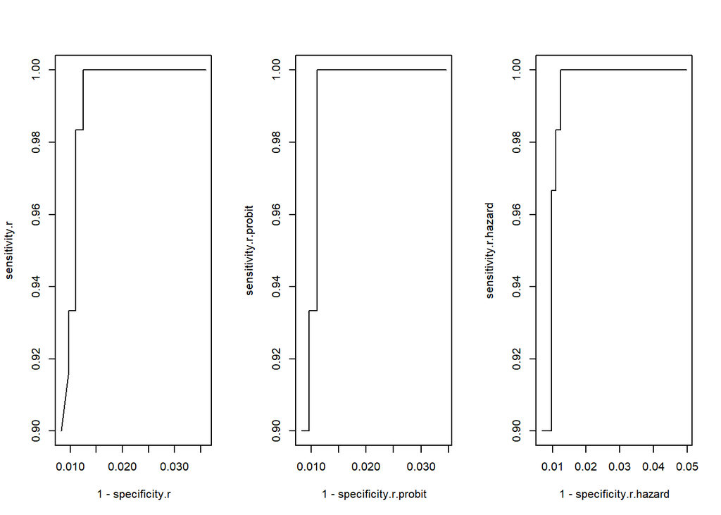

```r
thresh.r.hazard<-seq(0.01,0.5,0.01)
sensitivity.r.hazard<-specificity.r.hazard<-rep(NA,length(thresh.r.hazard))
for(j in seq(along=thresh.r.hazard)){
pp.r<-ifelse(faa_normal_r$predprob.r.hazard<thresh.r.hazard[j],"no","yes")
xx.r<-xtabs(~risky.landing+pp.r,faa_normal_r)
specificity.r.hazard[j]<-xx.r[1,1]/(xx.r[1,1]+xx.r[1,2])
sensitivity.r.hazard[j]<-xx.r[2,2]/(xx.r[2,1]+xx.r[2,2])
}
par(mfrow=c(1,3))
plot(1-specificity.r,sensitivity.r,type="l");abline(0,1,lty=2)
plot(1-specificity.r.probit,sensitivity.r.probit,type="l");abline(0,1,lty=2)
plot(1-specificity.r.hazard,sensitivity.r.hazard,type="l");abline(0,1,lty=2)
```

## 16. Predict Top 5 Risky Landings

64th value appears for all 3 link function and 56 appears for probit and hazard, rest all values are different

```r
head(sort(predprob.r, decreasing = TRUE),5)
```

```
## 364 309  64 389 410
##   1   1   1   1   1
```

```r
head(sort(predprob.r.probit, decreasing = TRUE),5)
```

```
##  56  64 136 178 181
##   1   1   1   1   1
```

```r
head(sort(predprob.r.hazard, decreasing = TRUE),5)
```

```
## 19 29 30 56 64
##  1  1  1  1  1
```

## 17. Confidence Interval for Probit & Hazard

From the below analysis it seems like the model with the hazard link function is more accurate fit compared to probit.

```r
pred.probit <- predict(model.probit.r,newdata=new.ind,type="response",se=T)
upper.probit <- ilogit(pred.probit$fit + (1.96 * pred.probit$se.fit))
lower.probit <- ilogit(pred.probit$fit - (1.96 * pred.probit$se.fit))
fit.probit <- ilogit(pred.probit$fit)

pred.hazard <- predict(model.hazard.r,newdata=new.ind,type="response",se=T)
upper.hazard <- ilogit(pred.hazard$fit + (1.96 * pred.hazard$se.fit))
lower.hazard <- ilogit(pred.hazard$fit - (1.96 * pred.hazard$se.fit))
fit.hazard <- ilogit(pred.hazard$fit)

cat("95% Confidence Interval for probit", "lower:", lower.probit, "| fit:" , fit.probit, "| upper:", upper.probit)
```

```
## 95% Confidence Interval for probit lower: 0.7310568 | fit: 0.7310584 | upper: 0.7310601
```

```r
cat("95% Confidence Interval for hazard", "lower:", lower.hazard, "| fit:" , fit.hazard, "| upper:", upper.hazard)
```

```
## 95% Confidence Interval for hazard lower: 0.7310586 | fit: 0.7310586 | upper: 0.7310586
```